# Assignment 2

Kylian van Noordenne - 450752

April 2021

```r
#install.packages("tseries")
#install.packages("forecast")
#install.packages("dplyr")
#install.packages("readxl)
#install.packages("openxlsx")

library(tseries)
library(forecast)
library(dplyr)
library(readxl)
library(openxlsx)
```

### Preprocess the data

```r
# Set working directory
setwd("~/BAM/Supply Chain Analytics/Assignment 2")

# Load data
ingredients <- read.csv("ingredients.csv")
menu_items <- read.csv("menu_items.csv")
menuitem <- read.csv("menuitem.csv")
portion_uom_types <- read.csv("portion_uom_types.csv")
pos_ordersale <- read.csv("pos_ordersale.csv")
recipe_ingredient_assignments <- read.csv("recipe_ingredient_assignments.csv")
recipe_sub_recipe_assignments <- read.csv("recipe_sub_recipe_assignments.csv")
recipes <- read.csv("recipes.csv")
store_restaurant <- read_excel("store_restaurant.xlsx")
sub_recipe_ingr_assignments <- read.csv("sub_recipe_ingr_assignments.csv")
sub_recipes <- read.csv("sub_recipes.csv")
```

#### Find the quantity of lettuce for each recipe

For each recipe,the amount of lettuce used by sub-recipes and corresponding recipes should be found. In the “ingredients” set we find that the ingredient number 27 is lettuce.

```r
# all recipes that contain lettuce
total_lettuce_recipes <- recipe_ingredient_assignments[recipe_ingredient_assignments$IngredientId == 27,c(1,3)]
total_lettuce_recipes
```

At this point all the recipes that contain lettuce are found. Currently, the corresponding sub_recipes should be found.

```r
# Subrecipes containing lettuce
sub_recipes_lettuce <- sub_recipe_ingr_assignments[sub_recipe_ingr_assignments$IngredientId == 27,]
sub_recipes_lettuce
```

7 subrecipes, contain lettuce (the ingedrientId of 27). The sub_recipes_lecture and recipe_sub_recipe_assignments need to be merged to find the corresponding subrecipes per recipe

```r
# Recipes containing a sub_recipe where lettuce is present
subrecipes_lettuce <- inner_join(sub_recipes_lettuce, recipe_sub_recipe_assignments, by = "SubRecipeId")
subrecipes_lettuce
```

Currently, the subrecipes where lettuce is present are defined. However, I do not know how much lettuce is present. This can be derived by multiplying the quantity times the factor.

```r
subrecipes_lettuce$Quantity <- subrecipes_lettuce$Quantity * subrecipes_lettuce$Factor
```

A still existing problem is that a recipe can have multiple subrecipes. Aggregating the total recipes based per subrecipe solves the issue.

```r
total_lettuce_subrecipes <- aggregate(cbind(Quantity) ~ RecipeId, sum, data = subrecipes_lettuce)
total_lettuce_subrecipes
```

The files Total_lettuce_recipes & Total_lettuce_subrecipes need to be aggregated for getting the total lettuce per recipe and subrecipe.

```r
# rbind the datasets
binded_data <- rbind(total_lettuce_recipes, total_lettuce_subrecipes)
```

```r
total_lettuce <- aggregate(cbind(Quantity) ~ RecipeId, sum, data = binded_data)
summary(total_lettuce)
```

We now obtained the total quantity of lettuce present per recipe, based on the subrecipes as well.

#### Find the quantity of lettuce for each store

The total quantity per recipe are retrieved. However, I still need to find the quantity of lettuce per store. This is done by finding the lettuce per menuitem.

First, we retrieve the lettuce per menuitem.

```r
# We want to inner join two dataframe. However, the naming isn't the same yet. Therefore, I change MenuItemID to Id
names(menu_items)[4] <- "Id"

# Now we can inner join both dataframe by Id
menuitem <- inner_join(menuitem, menu_items, by = "Id")
```

```r
menuitem <- inner_join(menuitem, total_lettuce, by = "RecipeId")
menuitem
```

We now have a Quantity.x and Quantity.y variable. Again we need to multiple these obtain the total quantity of lettuce per order.

```r
# Obtain the total quantity.
menuitem$total_lettuce <- menuitem$Quantity.x * menuitem$Quantity.y
```

Now let’s check the stores:

```r
# Check the store restaurant specifications
store_restaurant
```

Store number 46673 and 4904 are the 2 stores in Berkeley, CA. Store number 12631 and 20974 are the stores Ridgewood and Elmhurst, NY. We need retrieve the total lettuce per day per store.

```r
# Total lettuce per store number 46673 per day
store_46673 <- aggregate(cbind(total_lettuce) ~ date, sum,
                         data = menuitem[menuitem$StoreNumber == 46673, c(15, 21)])
```

```r
# Total lettuce per store number 4904 per day
store_4904 <- aggregate(cbind(total_lettuce) ~ date, sum,
                         data = menuitem[menuitem$StoreNumber == 4904, c(15, 21)])
```

```r
# Total lettuce per store number 12631 per day
store_12631 <- aggregate(cbind(total_lettuce) ~ date, sum,
                         data = menuitem[menuitem$StoreNumber == 12631, c(15, 21)])
```

```r
# Total lettuce per store number 20974 per day
store_20974 <- aggregate(cbind(total_lettuce) ~ date,
                         sum,
                         data = menuitem[menuitem$StoreNumber == 20974, c(15, 21)])
```

A problem with store 20974 is that the first six results seem wrong. Therefore, I remove those ‘outliers’ to obtain more accurate results.

```r
# Only use observations 7 up until 94
store_20974 <- store_20974[c(7:94),]
store_20974
```

A training and test set is created to gather an out-of-sample prediction. The task of the assignment is to create a prediction of two weeks. Therefore, I create a test set of the last 2 weeks in order to (hopefully) pick the best model based on the results of the last 2 weeks. I train on the remaining data.

```r
# STORE 46673 - Training set (first 82 days) & Test set
training_46673   <- ts(store_46673[1:89,2], frequency = 7)
test_46673 <- store_46673[90:nrow(store_46673),2]

# STORE 4904 - Training set (first 71 days) & Test set
training_4904   <- ts(store_4904[1:81,2], frequency = 7)
test_4904 <- store_4904[82:nrow(store_4904),2]

# STORE 12631 -  Training set (first 89 days) & Test set
training_12631  <- ts(store_12631[1:89,2], frequency = 7)
test_12631 <- store_12631[90:nrow(store_12631),2]

# STORE 20974 - Training set (first 74 days) & Test set
training_20974   <- ts(store_20974[1:74,2], frequency = 7)
test_20974 <- store_20974[75:nrow(store_20974),2]
```

I will elaborate one store 46673 in detail and I will briefly go over the other three stores (as of the page limitation)

### Forecast Store 46673

In order for the times series predictions to work, we need to convert the numerical store variable to a time series

```r
# Convert to time series
store_46673 <- ts(store_46673[, 2], frequency = 7, start = c(03, 5))
```

Let’s get more insights into our time series by creating the following plot. The *stl()* function allows us to visually inspect the created time series.

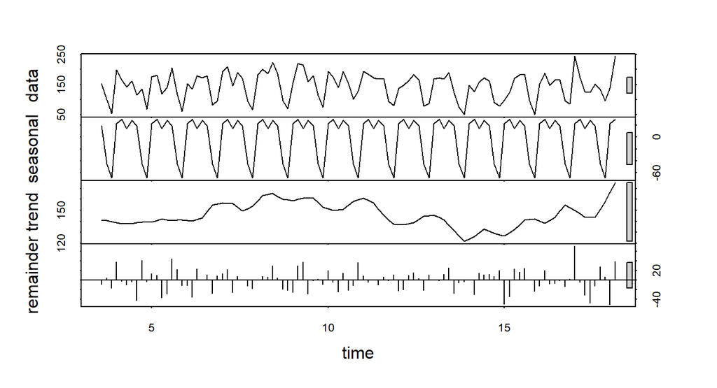

```r
plot(stl(store_46673, s.window = "period"))
```

#### Holt-Winters model

Let’s perform the HoltWinters function to find the parameters that lead to the minimum error

```r
# Parameter estimation
HW_store_46673 <- HoltWinters(training_46673)
HW_store_46673
```

The estimated alpha parameter is about 0.06. As this is pretty close to zero, it implies that more weight is placed on recent observations, but this is marginally. The beta is zero as there is no trend. The gamma, the coefficient for the seasonal smoothing, is 0.35.

Now let’s create an Exponential smoothing (ETS) model as well:

```r
ETS_store_46673 <- ets(training_46673, model = "ZZZ")
ETS_store_46673
```

The first letter is the error type, the second letter the trend type and the third letter denotes the season type. “N” means none, “A” means additive and “M” means multiplicative. In this case there is a A, N, A model. It means that there is no trend, but there is seasonality.

```r
# Predict the next 14 days based on the forecast
forecast_46673_HW <- forecast(HW_store_46673, h = 14)
```

```r
# Predict the next 14 days based on the forecast
forecast_46673_ETS <- forecast(ETS_store_46673, h = 14)
```

```r
# Check the model fit
checkresiduals(forecast_46673_ETS)
```

```r
checkresiduals(forecast_46673_HW)
```

There is one lag in the ETS model where the confidence interval is exceeded. Nevertheless, this is not the case for the HW model and both models show a normal distribution in the residuals. Therefore, I do not see any major warning signals. What is a warning signal, is that the Ljung-box p-value is < 0.05. This implies that we cannot assume that the values are dependent.

#### ARIMA

Check for stationarity

```r
# ADF test
adf.test(store_46673)
```

Assuming a p-value of 0.05: Our found P-value < 0.05. Therefore, the null hypothesis is rejected and it is highly likely that the time series is stationary.

```r
# PP test
pp.test(store_46673)
```

Assuming a p-value of 0.05: Our found P-value < 0.05. Therefore, the null hypothesis is rejected and it is highly likely that the time series is stationary.

```r
# KPSS test
kpss.test(store_46673)
```

Assuming a p-value of 0.05 is used: Our found P-value > 0.05. Therefore, the alternative hypothesis is rejected and it is proposed that it is highly likely that the time series is stationary.

Differencing is not needed as the time series are stationary. This is also confirmed if we use the ndiffs function:

```r
ndiffs(store_46673)
```

```r
# Determine ARIMA parameters
auto.arima(training_46673, ic = c('bic'), trace = TRUE)
```

```
##
##  ARIMA(2,0,2)(1,1,1)[7] with drift         : Inf
##  ARIMA(0,0,0)(0,1,0)[7] with drift         : 812.3871
##  ARIMA(1,0,0)(1,1,0)[7] with drift         : 797.7016
##  ARIMA(0,0,1)(0,1,1)[7] with drift         : 786.6812
##  ARIMA(0,0,0)(0,1,0)[7]                    : 808.0081
##  ARIMA(0,0,1)(0,1,0)[7] with drift         : 816.6708
##  ARIMA(0,0,1)(1,1,1)[7] with drift         : 791.0856
##  ARIMA(0,0,1)(0,1,2)[7] with drift         : 791.0858
##  ARIMA(0,0,1)(1,1,0)[7] with drift         : 797.5401
##  ARIMA(0,0,1)(1,1,2)[7] with drift         : Inf
##  ARIMA(0,0,0)(0,1,1)[7] with drift         : 785.0149
##  ARIMA(0,0,0)(1,1,1)[7] with drift         : 789.0588
##  ARIMA(0,0,0)(0,1,2)[7] with drift         : 789.1369
##  ARIMA(0,0,0)(1,1,0)[7] with drift         : 794.4818
##  ARIMA(0,0,0)(1,1,2)[7] with drift         : Inf
##  ARIMA(1,0,0)(0,1,1)[7] with drift         : 786.8519
##  ARIMA(1,0,1)(0,1,1)[7] with drift         : 791.0616
##  ARIMA(0,0,0)(0,1,1)[7]                    : 781.1482
##  ARIMA(0,0,0)(1,1,1)[7]                    : 785.3788
##  ARIMA(0,0,0)(0,1,2)[7]                    : 785.4227
##  ARIMA(0,0,0)(1,1,0)[7]                    : 790.0845
##  ARIMA(0,0,0)(1,1,2)[7]                    : 789.9197
##  ARIMA(1,0,0)(0,1,1)[7]                    : 782.8503
##  ARIMA(0,0,1)(0,1,1)[7]                    : 782.7104
##  ARIMA(1,0,1)(0,1,1)[7]                    : 787.1072
##
##  Best model: ARIMA(0,0,0)(0,1,1)[7]
```

```
## Series: training_46673
## ARIMA(0,0,0)(0,1,1)[7]
##
## Coefficients:
##          sma1
##       -0.7476
## s.e.   0.1199
##
## sigma^2 estimated as 680.8:  log likelihood=-386.17
## AIC=776.33   AICc=776.49   BIC=781.15
```

ARIMA(0,0,0)(0,1,1) with a period of 7 is the best performing model, closely followed by ARIMA(0,0,1)(0,1,1)[7]. These two specification are assigned to the Arima models. I used two Arima models as the differences in BIC is that marginal, that I cannot fully confirm that one Arima models outperforms the other Arima models. Therefore, I used the two best performing model based on the BIC value.

```r
# Create the models
model_store_46673_1 <- Arima(training_46673, order = c(0, 0, 0),
                           seasonal = list(order = c(0, 1, 1), period = 7))

model_store_46673_2 <- Arima(training_46673, order = c(0, 0, 1),
                           seasonal = list(order = c(0, 1, 1), period = 7))
```

The trained models will be used for gathering a 14 day forecast, as the test set is 14 days as well.

```r
# Forecast the models
forecast_store_46673_1 <- forecast(model_store_46673_1, h = 14)
forecast_store_46673_2 <- forecast(model_store_46673_2, h = 14)
```

```r
# Check the model fit
checkresiduals(forecast_store_46673_1)
```

```r
checkresiduals(forecast_store_46673_2)
```

Residuals are normally divided, but 2 lags tend to be slightly out of the confidence interval. This is not a huge problem, but it might be useful to investigate later. The Ljung-Box test shows a p-value of 0.0047 and 0.248. This implies that one model is likely to shows a lack of fit, while the other second Arima model is likely to fit.

#### Performance comparison: store 46673

The out-of-sample performance is evaluated to compare the performance of the models. The mean squared error is the criteria where our 2 week ahead prediction is judged on. Therefore, I will look another error metrics, but my decision is based on the lowest RMSE test set result. I mainly consider the test set, as this provides the predictory power of the model, rather then tells me how well my model fits the data.

```r
# Testing the models
accuracy(forecast_store_46673_1, test_46673) #ARIMA1
```

```
##                       ME     RMSE      MAE       MPE     MAPE      MASE
## Training set -0.06320554 24.89233 18.27833 -2.935965 13.78152 0.4262038
## Test set      8.67456799 41.49454 30.70063  3.132855 19.59288 0.7158599
##                   ACF1
## Training set 0.1811863
## Test set            NA
```

```r
accuracy(forecast_store_46673_2, test_46673) #ARIMA2
```

```
##                       ME     RMSE      MAE      MPE     MAPE      MASE
## Training set 0.002828693 24.33113 17.78837 -2.70520 13.37245 0.4147791
## Test set     7.493254846 41.08078 30.72942  2.31373 19.62275 0.7165311
##                     ACF1
## Training set 0.003568804
## Test set              NA
```

The second Arima model seems to perform better in training set as well as the out-of-sample performance as the RMSE error is lower. This confirms my initial thought that I cannot fully confirm that the Arima model with the lowest BIC value will outperform the other Arima models.

```r
# Testing the models
accuracy(forecast_46673_HW, test_46673) #HW
```

```
##                     ME     RMSE      MAE       MPE     MAPE      MASE
## Training set  2.549639 26.96123 21.16340 -1.543417 15.64948 0.4934762
## Test set     13.814484 44.13612 32.22918  6.952435 20.79991 0.7515018
##                    ACF1
## Training set 0.06004512
## Test set             NA
```

```r
accuracy(forecast_46673_ETS, test_46673) #ETS
```

```
##                     ME     RMSE      MAE       MPE     MAPE      MASE      ACF1
## Training set -1.014639 23.09898 18.47706 -3.708049 14.26531 0.4308376 0.0879864
## Test set     12.025567 38.53718 28.55525  5.920676 18.50333 0.6658351        NA
```

I gathered the error metrics for both models. Initially I found that the ETS model, based on the test set results, outperformed the HW model. Further, I found that my second ARIMA model had a better performance than my first ARIMA model. Moreover, I found that the ETS model outperformed the ARIMA models as well. I decided to use the ETS model as most criteria, and especially the squared deviation error, showed a lower error. Certain error metrics, such as the ME and MPE are in favor of the utilization of the Arima model. Yet, as stated, the RMSE is the most important metric and is the lowest for the out-of-sample ETS model.

Let’s now use the full ETS model to predict for the next 14 days. In this case, all the data is used rather than just the training data.

```r
store_46673_ETS <- ets(store_46673, model = "ZZZ")
store_46673_ETS
```

The model is now trained on all the data. As of now, I will forecast 14 unknown days ahead to retrieve our first forecast.

```r
# Predict the next 14 days
future_predictions_46673 <- forecast(store_46673_ETS, h = 14)
future_predictions_46673
```

```
##          Point Forecast     Lo 80     Hi 80     Lo 95    Hi 95
## 18.28571      159.54815 120.73789 198.35842 100.19297 218.9033
## 18.42857      172.45762 130.50711 214.40813 108.29985 236.6154
## 18.57143      161.76594 122.41619 201.11568 101.58570 221.9462
## 18.71429      100.50529  76.05727 124.95332  63.11526 137.8953
## 18.85714       78.87924  59.69178  98.06671  49.53455 108.2239
## 19.00000      169.94661 128.60690 211.28631 106.72299 233.1702
## 19.14286      176.33227 133.43925 219.22530 110.73305 241.9315
## 19.28571      159.54815 120.73788 198.35842 100.19297 218.9033
## 19.42857      172.45762 130.50711 214.40813 108.29985 236.6154
## 19.57143      161.76594 122.41619 201.11569 101.58569 221.9462
## 19.71429      100.50529  76.05726 124.95332  63.11526 137.8953
## 19.85714       78.87924  59.69177  98.06671  49.53454 108.2239
## 20.00000      169.94661 128.60690 211.28631 106.72299 233.1702
## 20.14286      176.33227 133.43925 219.22530 110.73305 241.9315
```

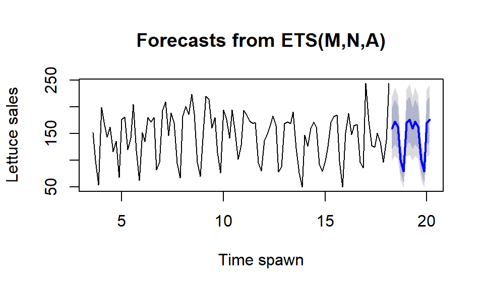

```r
plot(future_predictions_46673, xlab = "Time spawn", ylab = "Lettuce sales")
```

### Forecast: Other stores

As of the page limit, I will combine the three other stores and do not display most plots. I did check and investigate my output, but I will not display most of it in the R markdown file.

#### Holt-Winters model

```r
# Convert to time series
store_4904 <- ts(store_4904[, 2], frequency = 7, start = c(03, 13))
store_12631 <- ts(store_12631[, 2], frequency = 7, start = c(03, 20))
store_20974 <- ts(store_20974[, 2], frequency = 7, start = c(03, 5))
```

```r
# Plot the time series
plot(stl(store_4904, s.window = "period"))
```

```r
plot(stl(store_12631, s.window = "period"))
```

```r
plot(stl(store_20974, s.window = "period"))
```

```r
# Parameter estimation of the stores
training_4904_HW <- HoltWinters(training_4904)
training_12631_HW <- HoltWinters(training_12631)
training_20974_HW <- HoltWinters(training_20974)
```

```r
training_4904_ETS <- ets(training_4904, model = "ZZZ")
training_12631_ETS <- ets(training_12631, model = "ZZZ")
training_20974_ETS <- ets(training_20974, model = "ZZZ")
```

ETS_store_4904: A,N,A model - ETS_store_12631: M,Ad,M model - ETS_store_20974: A,N,A model.

Let’s train on the training set.

```r
# Predict the next 14 days based on the forecast
forecast_4904_HW <- forecast(training_4904_HW, h = 14)
```

```r
# Predict the next 14 days based on the forecast
forecast_12631_HW <- forecast(training_12631_HW, h = 14)
```

```r
# Predict the next 21 days based on the forecast
forecast_20974_HW <- forecast(training_20974_HW, h = 14)
```

Now let’s also train and plot the ETS forecasts for the stores:

```r
# Predict the next 14 days based on the forecast
forecast_4904_ETS <- forecast(training_4904_ETS, h = 14)
```

```r
# Predict the next 14 days based on the forecast
forecast_12631_ETS <- forecast(training_12631_ETS, h = 14)
```

```r
# Predict the next 14 days based on the forecast
forecast_20974_ETS <- forecast(training_20974_ETS, h = 14)
```

Investigate the residuals of our models

```r
# Examine model fit
checkresiduals(forecast_4904_ETS)
```

```r
checkresiduals(forecast_4904_HW)
```

Ljung-box p-value < 0.05, so we cannot assume that the values are dependent. The plots do not show warning signals as the residuals are normally distributed and the lags of both models are within the confidence intervals.

```r
# Examine model fit
checkresiduals(forecast_12631_ETS)
```

```r
checkresiduals(forecast_12631_HW)
```

Ljung-box p-value < 0.05, so we cannot assume that the values are dependent. This is a warning signal. The plots do not show warning signals as the residuals are normally distributed and the lags of both models are within the confidence intervals.

```r
# Examine model fit
checkresiduals(forecast_20974_ETS)
```

```r
checkresiduals(forecast_20974_HW)
```

Ljung-box p-value < 0.05, so we cannot assume that the values are dependent. This is a warning signal. The plots do not show warning signals as the residuals are normally distributed and the lags of both models are within the confidence intervals.

#### ARIMA for all stores

```r
# ADF test
adf.test(store_4904)
adf.test(store_12631)
adf.test(store_20974)
```

Assuming a p-value of 0.05 is used: the found P-value is < 0.05. Therefore, the null hypothesis is rejected and it is proposed that it is highly likely that the time series is stationary.

```r
# PP test
pp.test(store_4904)
pp.test(store_12631)
pp.test(store_20974)
```

Assuming a p-value of 0.05 is used: the found P-value is < 0.05. Therefore, the null hypothesis is rejected and it is proposed that it is highly likely that the time series is stationary.

```r
# KPSS test
kpss.test(store_4904)
kpss.test(store_12631)
kpss.test(store_20974)
```

Assuming a p-value of 0.05 is used: the found P-value is > 0.05. Therefore, the alternative hypothesis is rejected and it is proposed that it is highly likely that the time series is stationary for store 4904 and 20974.

Differencing is not needed for store 4904 and store 20974 as the time series are stationary. This is also confirmed if the ndiffs function is applied:

```r
ndiffs(store_4904)
ndiffs(store_20974)
```

However, if we check store 12631, a ndiffs of 1 is found:

```r
ndiffs(store_12631)
```

The Arima model should tackle this problem. The test set result is the exact same when applying the differences of 1 (d = 1).

```r
# ARIMA store 4904
auto.arima(training_4904, ic = c('bic'), trace = TRUE)
```

ARIMA(0,0,0)(2,1,0)[7] with a period of 7 is the best performing models. Closely followed by ARIMA(1,0,1)(2,1,0)[7]. These two specifications are assigned to the Arima training models.

```r
# Create the models
model_store_4904_1 <- Arima(training_4904, order = c(0, 0, 0),
                           seasonal = list(order = c(2, 1, 0), period = 7))

model_store_4904_2 <- Arima(training_4904, order = c(1, 0, 1),
                           seasonal = list(order = c(2, 1, 0), period = 7))
```

```r
# ARIMA store 12631
auto.arima(training_12631, ic = c('bic'), trace = TRUE)
```

ARIMA(0,1,1)(2,0,0) with a period of 7 is the best performing models. closely followed by ARIMA(1,1,1)(1,0,0)[7]. These two specifications are assigned to the Arima training models.

```r
# Create the models
model_store_12631_1 <- Arima(training_12631, order = c(0, 1, 1),
                           seasonal = list(order = c(2, 0, 0), period = 7))

model_store_12631_2 <- Arima(training_12631, order = c(1, 1, 1),
                           seasonal = list(order = c(1, 0, 0), period = 7))
```

Lastly, I create the model for store 20974.

```r
# ARIMA store 20974
auto.arima(training_20974, ic = c('bic'), trace = TRUE)
```

ARIMA(1,0,0)(1,0,0)[7] with a period of 7 is the best performing models. closely followed by ARIMA(0,0,1)(1,0,0)[7]. These two specifications are assigned to the Arima training models.

```r
# Create the models
model_store_20974_1 <- Arima(training_20974, order = c(1, 0, 0),
                           seasonal = list(order = c(1, 0, 0), period = 7))

model_store_20974_2 <- Arima(training_20974, order = c(0, 0, 1),
                           seasonal = list(order = c(1, 0, 0), period = 7))
```

I will now forecast the ARIMA models.

```r
# ARIMA forecast store 4904
forecast_store_4904_1 <- forecast(model_store_4904_1, h = 14)
forecast_store_4904_2 <- forecast(model_store_4904_2, h = 14)

# ARIMA forecast store 12631
forecast_store_12631_1 <- forecast(model_store_12631_1, h = 14)
forecast_store_12631_2 <- forecast(model_store_12631_2, h = 14)

# ARIMA forecast store 20974
forecast_store_20974_1 <- forecast(model_store_20974_1, h = 14)
forecast_store_20974_2 <- forecast(model_store_20974_2, h = 14)
```

### Performance comparison other stores

At this point, all training sets are trained and I can compare the performance based on a prediction of the training set on the test set. I will assess the performance per store. Again, the main criteria will be the test set RMSE metric, as I want to assess the predictory power based on the mean squared deviation.

#### Performance comparison: Store 4904

```r
accuracy(forecast_store_4904_1, test_4904) #ARIMA1
accuracy(forecast_store_4904_2, test_4904) #ARIMA2

accuracy(forecast_4904_HW, test_4904) # HW
accuracy(forecast_4904_ETS, test_4904) #ETS
```

The ARIMA outperformed the HW model and the ETS model, based on the RMSE criteria. Therefore, I propose the utilization of the ARIMA model.

```r
# Train a new model based on all data
store_4904_ARIMA <- Arima(store_4904, order = c(0, 0, 0),
                           seasonal = list(order = c(2, 1, 0), period = 7))
```

```r
# Predict the next 14 days
future_predictions_4904 <- forecast(store_4904_ARIMA, h = 14)
```

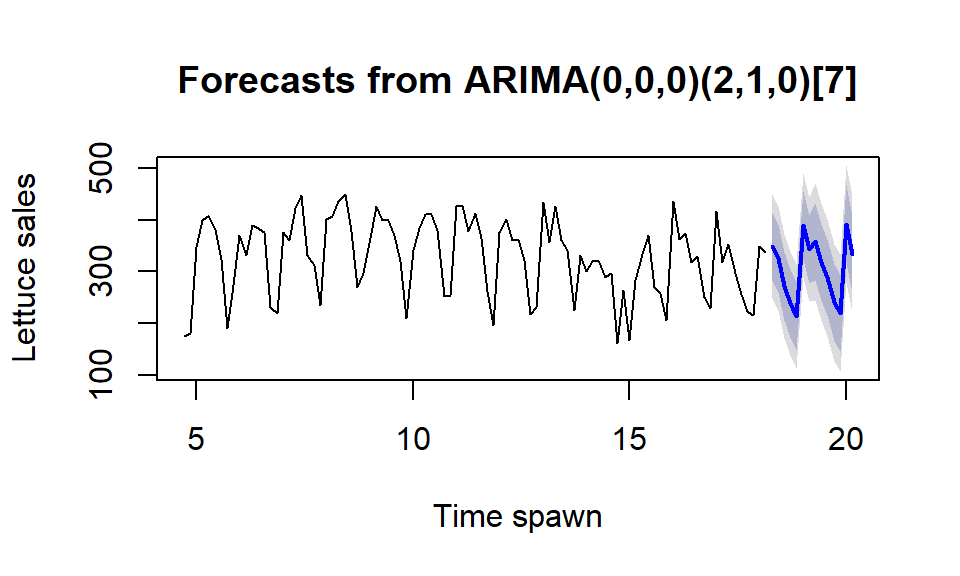

```r
# Plot future predictions
plot(future_predictions_4904, xlab = "Time spawn", ylab = "Lettuce sales")
```

#### Performance comparison: Store 12631

```r
accuracy(forecast_store_12631_1, test_12631) #ARIMA1
accuracy(forecast_store_12631_2, test_12631) #ARIMA2

accuracy(forecast_12631_HW, test_12631) # HW
accuracy(forecast_12631_ETS, test_12631) #ETS
```

The HW outperformed the ETS model, as well as the ARIMA models, based the most important error criteria (RMSE). Therefore, I propose the utilization of the HW model. I will now train the model on all the data and predict the next 14 days.

```r
HW_store_12631 <- HoltWinters(store_12631)
```

```r
# Predict the next 14 days
future_predictions_12631 <- forecast(HW_store_12631, h = 14)
```

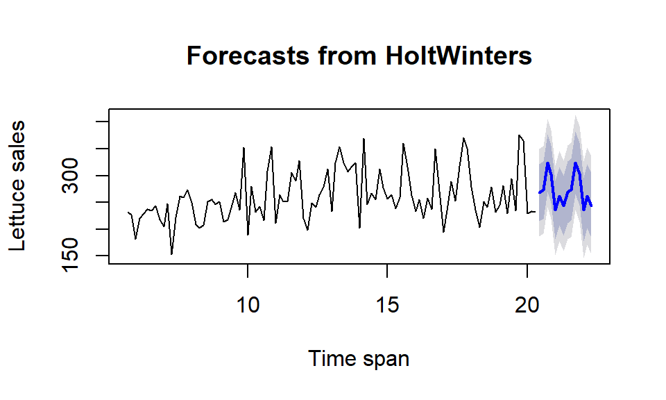

```r
plot(future_predictions_12631, xlab = "Time span", ylab = "Lettuce sales")
```

#### Performance comparison: Store 20974

```r
accuracy(forecast_store_20974_1, test_20974) #ARIMA1
accuracy(forecast_store_20974_2, test_20974) #ARIMA2

accuracy(forecast_20974_HW, test_20974) # HW
accuracy(forecast_20974_ETS, test_20974) #ETS
```

```r
# Train a new model based on all data
store_20974_ARIMA <- Arima(store_20974, order = c(0, 0, 1),
                           seasonal = list(order = c(1, 0, 0), period = 7))
```

```r
# Predict the next 14 days
future_predictions_20974 <- forecast(store_20974_ARIMA, h = 14)
```

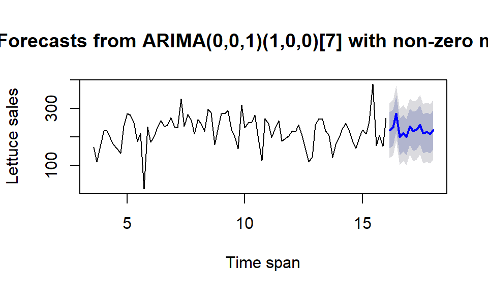

```r
plot(future_predictions_20974, xlab = "Time span", ylab = "Lettuce sales")
```

### Forecasts for all stores

```r
# Assign predictions to dataframe
final_predictions <- as.data.frame(future_predictions_46673$mean)
final_predictions$store_4904 <- future_predictions_4904$mean
final_predictions$store_12631 <- future_predictions_12631$mean
final_predictions$store_20974 <- future_predictions_20974$mean

#Change column name
names(final_predictions)[1] <- "store_46673"

# Display all predictions
final_predictions
```

| store_46673 | store_4904 | store_12631 | store_20974 |
| --- | --- | --- | --- |
| 159.54815 | 349.3644 | 268.6823 | 223.7116 |
| 172.45762 | 325.3364 | 273.3006 | 233.0270 |
| 161.76594 | 272.2177 | 323.9277 | 282.8869 |
| 100.50529 | 239.1307 | 302.5910 | 200.0428 |
| 78.87924 | 214.8122 | 235.7581 | 213.8501 |
| 169.94661 | 389.2001 | 261.8263 | 198.8921 |
| 176.33227 | 342.9655 | 243.9949 | 236.8624 |
| 159.54815 | 358.0636 | 269.1125 | 220.6432 |
| 172.45762 | 318.6171 | 273.7308 | 224.2160 |
| 161.76594 | 289.1383 | 324.3579 | 243.3391 |

[output cut: 4 more lines]

Let’s save all the final predictions into a csv file.

```r
write.csv(final_predictions, "Predictions submission 450752KN.csv")
```